# MATH 2310 Lab 4

lolita kim

## Introduction

In this lab you will explore another data set about vehicle performance very similar to to the data set we looked at in class for Lab 3. You will use the tools developed in the course so far to explore the data and then build some predictions for data that you have yet to see.

## Import Libraries

Below are some packages you may want to use. ISLR2 is a new pacakage you will need to obtain the data for this problem. Install the packages first but don’t include the install command in your knited document. You only need to run the install command once, then just run the library function each time you run you script.

```r
#install.packages('tidyverse', 'GGally','rstatix','Stat2Data','ggpubr') #Run this code once.
library(tidyverse)
library(rstatix)
library(Stat2Data)
library(ggpubr)
library(GGally)
library(ISLR2)
```

## Load the Data

Once you have loaded the ISLR2 package, the data set we will use is called Auto

```r
df = Auto
df$origin <- as.factor(df$origin) #Convert this column to a factor.
df$ordered <- as.ordered(df$year) #Convert this column to an ordered factor.

Auto
```

|  | mpg | cylinders | displacement | horsepower | weight | acceleration | year | origin | name |
| --- | --- | --- | --- | --- | --- | --- | --- | --- | --- |
| 1 | 18.0 | 8 | 307.0 | 130 | 3504 | 12.0 | 70 | 1 | chevrolet chevelle malibu |
| 2 | 15.0 | 8 | 350.0 | 165 | 3693 | 11.5 | 70 | 1 | buick skylark 320 |
| 3 | 18.0 | 8 | 318.0 | 150 | 3436 | 11.0 | 70 | 1 | plymouth satellite |
| 4 | 16.0 | 8 | 304.0 | 150 | 3433 | 12.0 | 70 | 1 | amc rebel sst |
| 5 | 17.0 | 8 | 302.0 | 140 | 3449 | 10.5 | 70 | 1 | ford torino |
| 6 | 15.0 | 8 | 429.0 | 198 | 4341 | 10.0 | 70 | 1 | ford galaxie 500 |
| 7 | 14.0 | 8 | 454.0 | 220 | 4354 | 9.0 | 70 | 1 | chevrolet impala |
| 8 | 14.0 | 8 | 440.0 | 215 | 4312 | 8.5 | 70 | 1 | plymouth fury iii |
| 9 | 14.0 | 8 | 455.0 | 225 | 4425 | 10.0 | 70 | 1 | pontiac catalina |
| 10 | 15.0 | 8 | 390.0 | 190 | 3850 | 8.5 | 70 | 1 | amc ambassador dpl |

[output cut: 382 more lines]

## Explore the data

Complete each of the following. Include text to, summarize, state what you see and make any conclusions.

- Look up `Auto` in the help to see a description of the data (You don’t need to show any R code, but you should write some text to summarize what you see). State clearly which variables in the data set are numeric (continuous/discrete) and which are categorical (nominal/ordinal). Continuous variables: mpg, displacement, acceleration Discrete variables: cylinders, horsepower, weight, year Categorical variables: name, origin
- View a few rows of the data set.
- Review the summary of each of the numeric variables and summarize any observations.

```r
for (i in 1:7){
  print(names(df)[i])
  print(
    summary(df[,i]))
}
```

```
## [1] "mpg"
##    Min. 1st Qu.  Median    Mean 3rd Qu.    Max.
##    9.00   17.00   22.75   23.45   29.00   46.60
## [1] "cylinders"
##    Min. 1st Qu.  Median    Mean 3rd Qu.    Max.
##   3.000   4.000   4.000   5.472   8.000   8.000
## [1] "displacement"
##    Min. 1st Qu.  Median    Mean 3rd Qu.    Max.
##    68.0   105.0   151.0   194.4   275.8   455.0
## [1] "horsepower"
##    Min. 1st Qu.  Median    Mean 3rd Qu.    Max.
##    46.0    75.0    93.5   104.5   126.0   230.0
## [1] "weight"
##    Min. 1st Qu.  Median    Mean 3rd Qu.    Max.
##    1613    2225    2804    2978    3615    5140
## [1] "acceleration"
##    Min. 1st Qu.  Median    Mean 3rd Qu.    Max.
##    8.00   13.78   15.50   15.54   17.02   24.80
## [1] "year"
##    Min. 1st Qu.  Median    Mean 3rd Qu.    Max.
##   70.00   73.00   76.00   75.98   79.00   82.00
```

```r
dim(Auto)
```

```
## [1] 392   9
```

```r
sqrt(392)
```

```
## [1] 19.79899
```

- There are 392 observations.

## Single variable investigation

- Make histograms for mpg, displacement, horsepower weight, and acceleration. Make sure to set the number of bins appropriately. Included any observations.

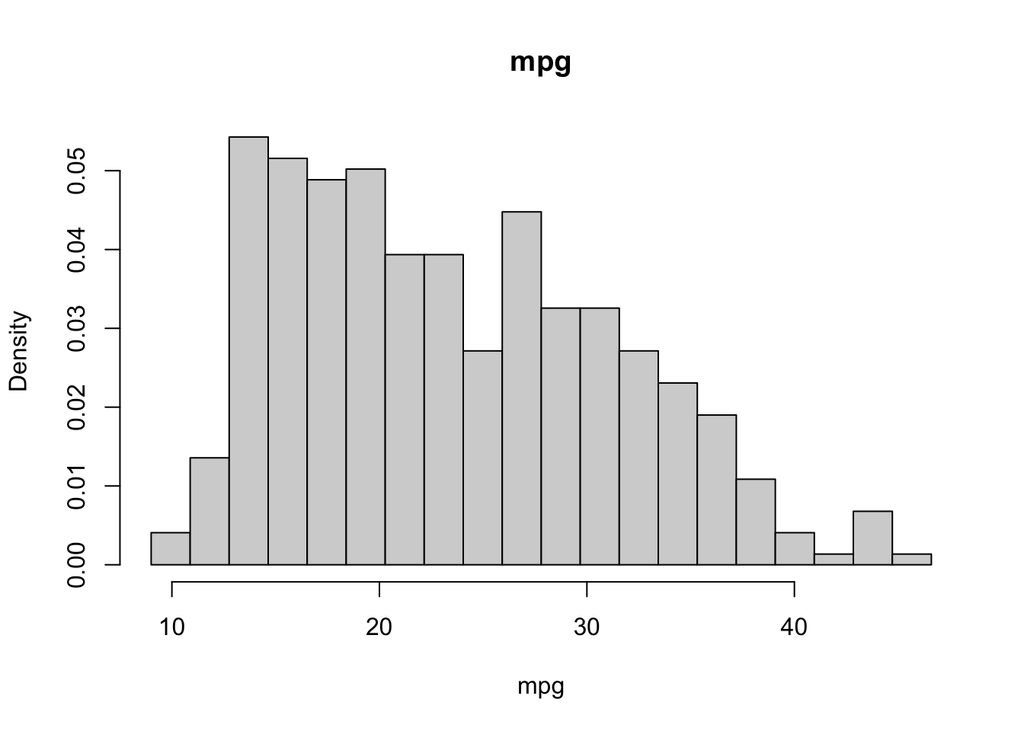

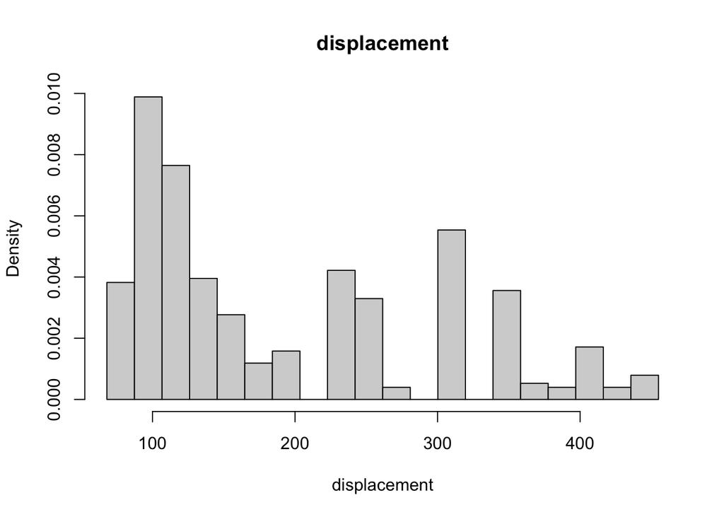

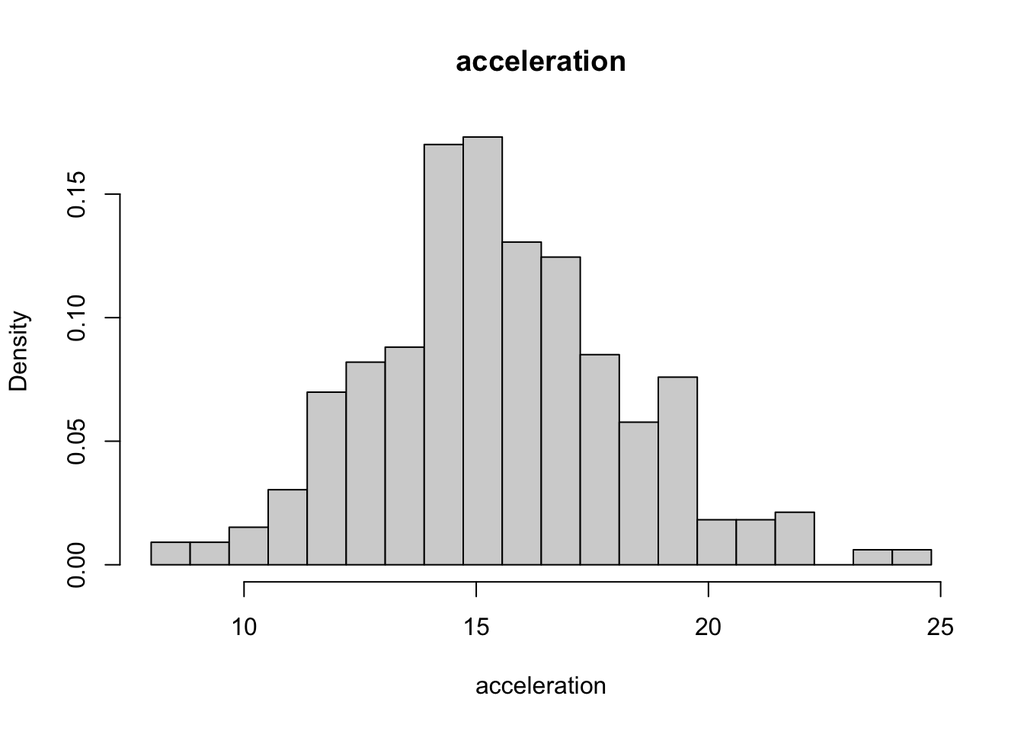

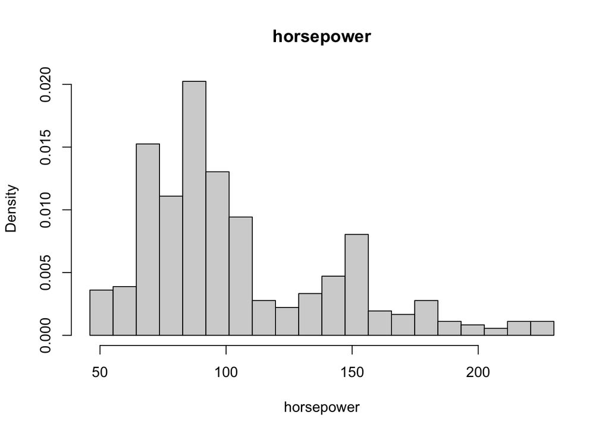

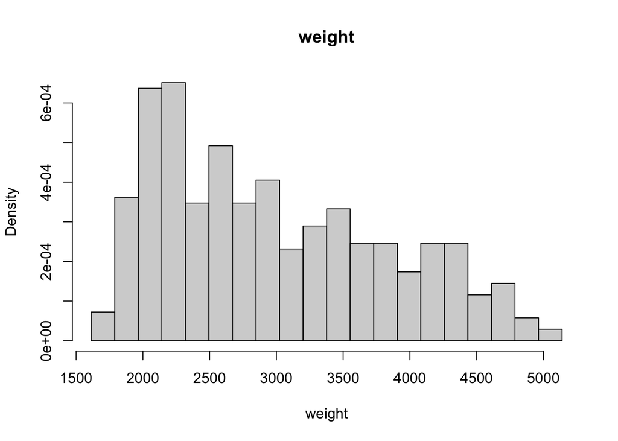

```r
histdat = df %>% select(mpg, displacement, acceleration, horsepower, weight) # select only the columns you want
for (i in 1:5){   # For loop that will create the histogram for each column.  histdat[,i] is the ith column of the table histdat
  hist(histdat[,i], breaks= seq(min(histdat[,i]), max(histdat[,i]), length.out = 21), freq=FALSE
       , main=paste0(names(histdat)[i])
       , xlab=paste0(names(histdat)[i]))
}
```

- Make box plots for mpg, displacement, horsepower, weight, and acceleration. Include any observations.

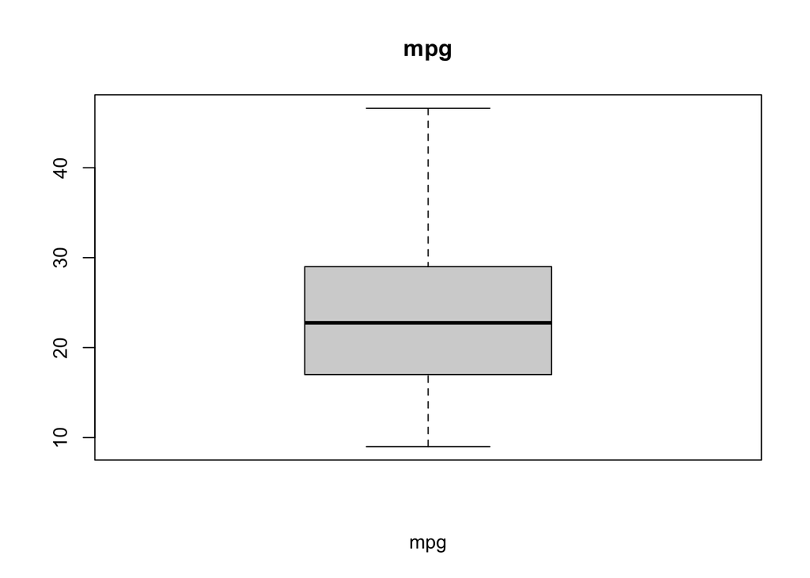

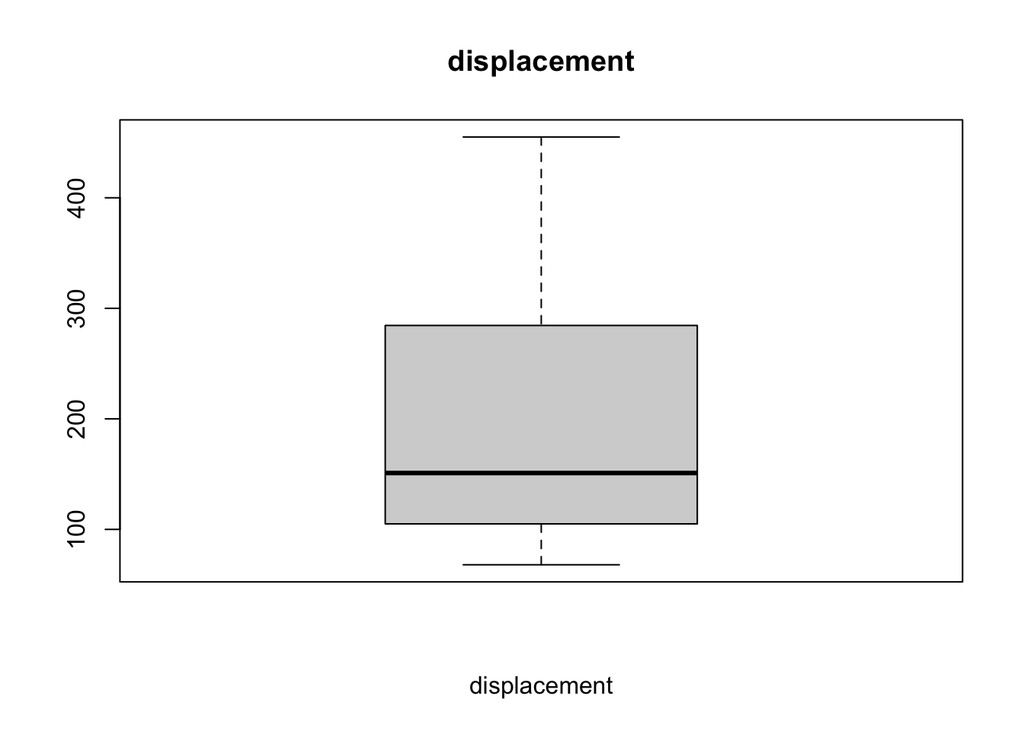

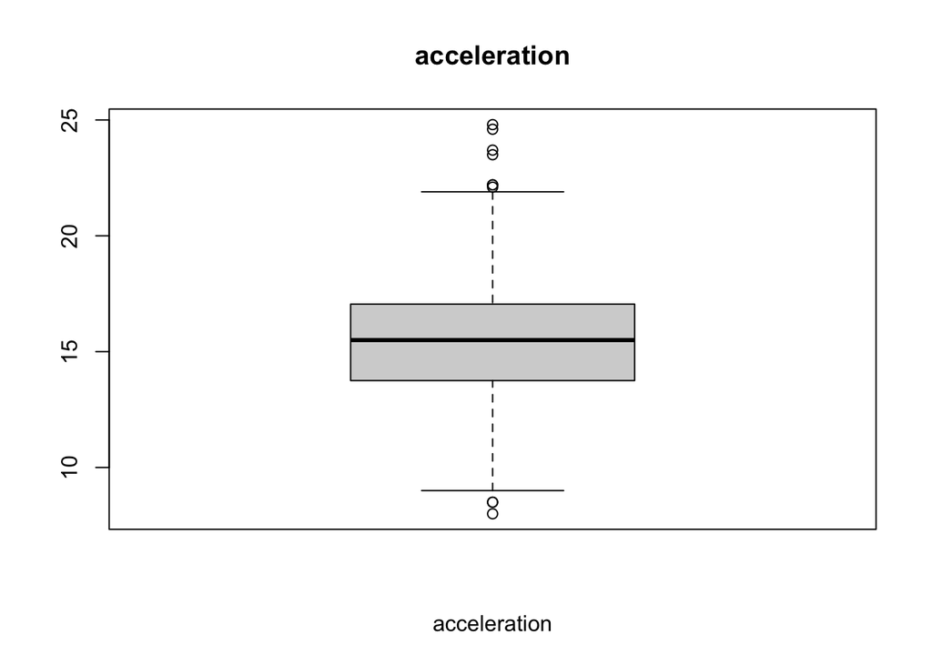

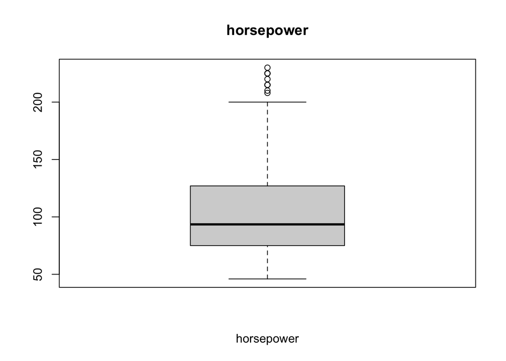

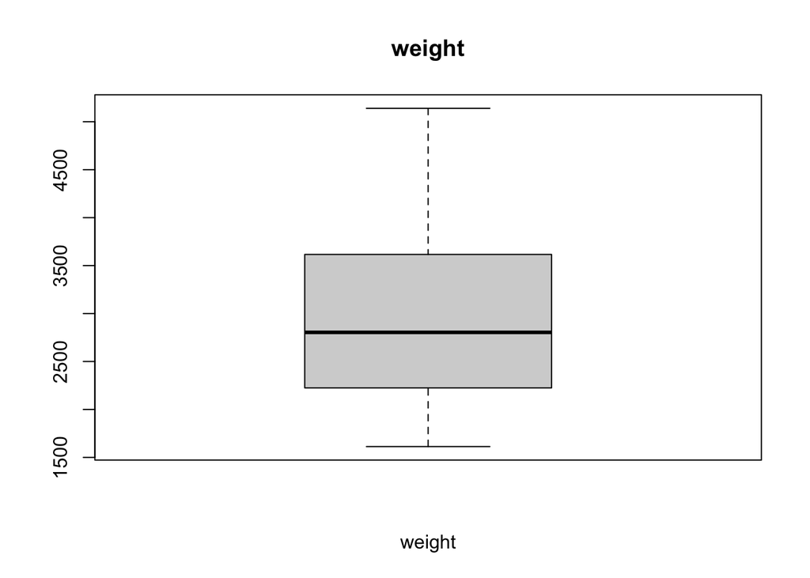

```r
for (i in 1:5){  #for loop that makes a box plot for each. histdat[, i] is the ith column.
  boxplot(histdat[,i], freq=FALSE
       , main=paste0(names(histdat)[i])
       , xlab=paste0(names(histdat)[i]))
}
```

- Find any outliers for each of mpg, displacement, horsepower, weight, or acceleration.

```r
# Use a built in function
for (i in 1:5) {
  Outliers = df %>% identify_outliers(names(histdat)[i])
  print(Outliers)
}
```

```
##  [1] mpg          cylinders    displacement horsepower   weight
##  [6] acceleration year         origin       name         ordered
## [11] is.outlier   is.extreme
## <0 rows> (or 0-length row.names)
##  [1] mpg          cylinders    displacement horsepower   weight
##  [6] acceleration year         origin       name         ordered
## [11] is.outlier   is.extreme
## <0 rows> (or 0-length row.names)
##     mpg cylinders displacement horsepower weight acceleration year origin
## 1  14.0         8          440        215   4312          8.5   70      1
## 2  15.0         8          390        190   3850          8.5   70      1
## 3  14.0         8          340        160   3609          8.0   70      1
## 4  23.0         4           97         54   2254         23.5   72      2
## 5  29.0         4           85         52   2035         22.2   76      1
## 6  24.5         4           98         60   2164         22.1   76      1
```

[output cut: 43 more lines]

## Multiple Variable Comparison

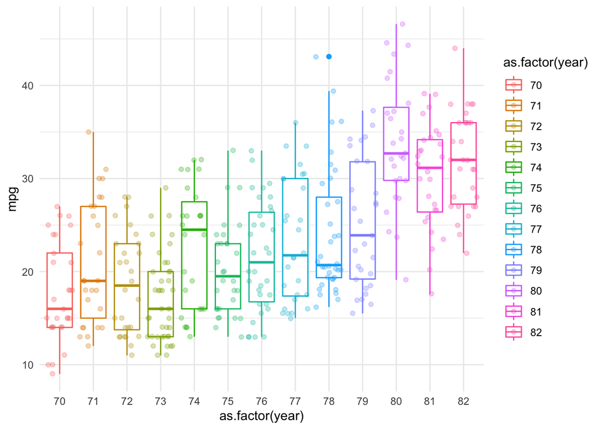

```r
ggplot(df, aes(x=as.factor(year), y = mpg, color=as.factor(year)))+ #Format (dataset, aes(x= xvaraible, y=yvariable, color= color variable))
    geom_boxplot() + #plot type
    geom_jitter(alpha=.3) + #add jitter, alpha controls the opacity of the jitter points
    theme_minimal()
```

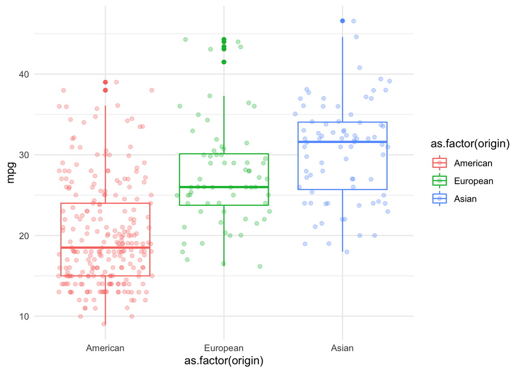

```r
levels(df$origin)<-c('American', 'European', 'Asian')
ggplot(df, aes(x=as.factor(origin), y = mpg, color=as.factor(origin)))+ #Format (dataset, aes(x= xvaraible, y=yvariable, color= color variable))
    geom_boxplot() + #plot type
    geom_jitter(alpha=.3) + #add jitter, alpha controls the opacity of the jitter points
    theme_minimal()
```

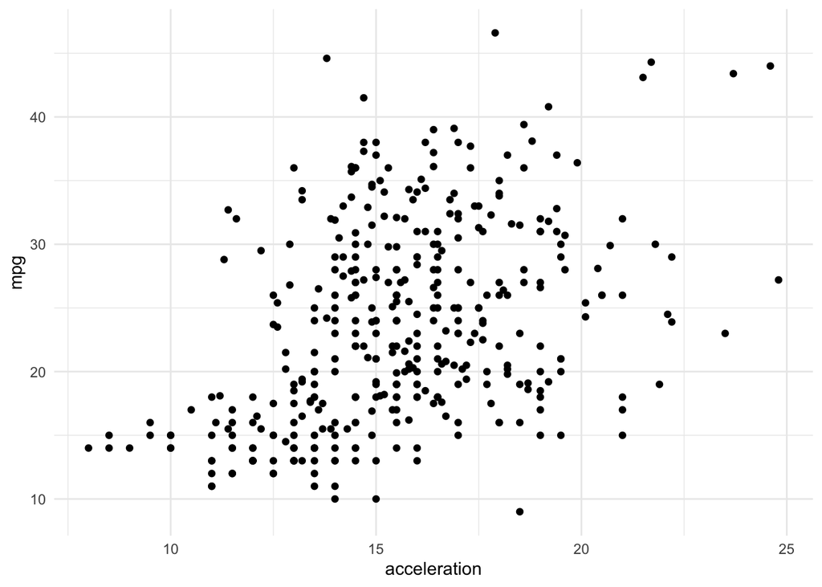

```r
ggplot(df,  aes(x = acceleration,y=mpg))+  #Format (dataset, aes(x= xvaraible, y=yvariable))
    geom_point()+ # this says to plot points
    theme_minimal() # This is optional
```

## Regression

- Calculate the correlation for all numeric variables. Find the two variables that are the most correlated with mpg. Weight and Displacement .
- For each of the variables found in the step above create a regression equation predicting miles per gallon. Show the equation, the $r^2$, the standard deviation of the residuals. Then create a scatter plot for each including the regression line plot. You should have two of everything - equation, $r^2$, standard deviations, and plots. Weight: y = 46.2 - 0.007647x Displacement: y = 35.12064 - 0.06005x
- Explain which of the two regressions you think is better and why. Generally, you choose the models that have higher adjusted and predicted R-squared values. These statistics are designed to avoid a key problem with regular R-squared—it increases every time you add a predictor and can trick you into specifying an overly complex model. That’s why I think the weight function is better than the displacement one as its r^2(0.6918) is bigger than the r^2 of displacement, which is 0.6473.
- In words explain why using multiple regression might be better in this case. The adjusted R squared increases only if the new term improves the model more than would be expected by chance and it can also decrease with poor quality predictors.

```r
cor(df%>% select_if(is.numeric))
```

```
##                     mpg  cylinders displacement horsepower     weight
## mpg           1.0000000 -0.7776175   -0.8051269 -0.7784268 -0.8322442
## cylinders    -0.7776175  1.0000000    0.9508233  0.8429834  0.8975273
## displacement -0.8051269  0.9508233    1.0000000  0.8972570  0.9329944
## horsepower   -0.7784268  0.8429834    0.8972570  1.0000000  0.8645377
## weight       -0.8322442  0.8975273    0.9329944  0.8645377  1.0000000
## acceleration  0.4233285 -0.5046834   -0.5438005 -0.6891955 -0.4168392
## year          0.5805410 -0.3456474   -0.3698552 -0.4163615 -0.3091199
##              acceleration       year
## mpg             0.4233285  0.5805410
## cylinders      -0.5046834 -0.3456474
## displacement   -0.5438005 -0.3698552
## horsepower     -0.6891955 -0.4163615
## weight         -0.4168392 -0.3091199
## acceleration    1.0000000  0.2903161
## year            0.2903161  1.0000000
```

```r
leastsquarfit = lm(mpg ~ weight, data=df) #Lots of models have this same format - modeltype(response ~explanatory, data)
leastsquarfit
```

```
##
## Call:
## lm(formula = mpg ~ weight, data = df)
##
## Coefficients:
## (Intercept)       weight
##   46.216525    -0.007647
```

```r
summary(leastsquarfit)
```

```
##
## Call:
## lm(formula = mpg ~ weight, data = df)
##
## Residuals:
##      Min       1Q   Median       3Q      Max
## -11.9736  -2.7556  -0.3358   2.1379  16.5194
##
## Coefficients:
##              Estimate Std. Error t value Pr(>|t|)
## (Intercept) 46.216524   0.798673   57.87   <2e-16 ***
## weight      -0.007647   0.000258  -29.64   <2e-16 ***
## ---
## Signif. codes:  0 '***' 0.001 '**' 0.01 '*' 0.05 '.' 0.1 ' ' 1
##
## Residual standard error: 4.333 on 390 degrees of freedom
## Multiple R-squared:  0.6926, Adjusted R-squared:  0.6918
## F-statistic: 878.8 on 1 and 390 DF,  p-value: < 2.2e-16
```

```r
leastsquarfit = lm(mpg ~ displacement, data=df) #Lots of models have this same format - modeltype(response ~explanatory, data)
leastsquarfit
```

```
##
## Call:
## lm(formula = mpg ~ displacement, data = df)
##
## Coefficients:
##  (Intercept)  displacement
##     35.12064      -0.06005
```

```r
summary(leastsquarfit)
```

```
##
## Call:
## lm(formula = mpg ~ displacement, data = df)
##
## Residuals:
##      Min       1Q   Median       3Q      Max
## -12.9170  -3.0243  -0.5021   2.3512  18.6128
##
## Coefficients:
##              Estimate Std. Error t value Pr(>|t|)
## (Intercept)  35.12064    0.49443   71.03   <2e-16 ***
## displacement -0.06005    0.00224  -26.81   <2e-16 ***
## ---
## Signif. codes:  0 '***' 0.001 '**' 0.01 '*' 0.05 '.' 0.1 ' ' 1
##
## Residual standard error: 4.635 on 390 degrees of freedom
## Multiple R-squared:  0.6482, Adjusted R-squared:  0.6473
## F-statistic: 718.7 on 1 and 390 DF,  p-value: < 2.2e-16
```